# Discrete & Continuous Probability Distributions

Author

Guibril Ramde

## Homework 3

A hospital wants to improve staffing by understanding patient arrivals and treatment times.

```r
#download Arrivals csv file and Treatment csv file


library(tidyverse)
arrivals_data <- read.csv("arrivals.csv")
arrivals_data
```

```
   Hour Patients
1     1       18
2     2       24
3     3       20
4     4       16
5     5       19
6     6       30
7     7       28
8     8       25
9     9       33
10   10       27
11   11       21
12   12       17
13   13       20
14   14       26
15   15       23
16   16       31
17   17       29
18   18       35
19   19       22
20   20       18
```

```r
treatments_data <- read_csv("treatment_times.csv")
treatments_data
```

```
# A tibble: 15 × 2
   PatientID TreatmentMinutes
       <dbl>            <dbl>
 1         1               32
 2         2               27
 3         3               45
 4         4               19
 5         5               55
 6         6               40
 7         7               29
 8         8               38
 9         9               44
10        10               22
11        11               31
12        12               36
13        13               47
14        14               24
15        15               52
```

**##Part A: Patient Arrivals**

1. **Compute descriptive statistics**

```r
#Summary of data
summary(arrivals_data)
```

```
      Hour          Patients
 Min.   : 1.00   Min.   :16.00
 1st Qu.: 5.75   1st Qu.:19.75
 Median :10.50   Median :23.50
 Mean   :10.50   Mean   :24.10
 3rd Qu.:15.25   3rd Qu.:28.25
 Max.   :20.00   Max.   :35.00
```

```r
#descriptive  statistics
arrival_mean <- mean(arrivals_data$Patients)
arrival_mean
```

```
[1] 24.1
```

```r
arrival_sd <- sd(arrivals_data$Patients)
arrival_sd
```

```
[1] 5.609203
```

```r
arrival_var <- var(arrivals_data$Patients)
arrival_var
```

```
[1] 31.46316
```

2. **Determine whether a Poisson distribution is appropriate.**

   **##Interpretation:**

   The mean number of arrivals is 24.1 and the variance is approximately 31.46. For a Poisson distribution, the mean and variance should be approximately equal. Although the variance is somewhat larger than the mean, the values are reasonably close, so a Poisson distribution may be an appropriate model for the patient arrivals.
3. **Estimate the arrival rate parameter.**

   ```r
   lambda <- mean(arrivals_data$Patients)
   lambda
   ```

   ```
   [1] 24.1
   ```

##Interpretation:

The estimated arrival rate is 24.1 patients per hour, meaning the hospital receives approximately 24 patients per hour on average.

4. **Calculate the probability of more than 30 arrivals in an hour.**

   ```r
   proportion_arr <- mean(arrivals_data$Patients > 30)
   proportion_arr
   ```

   ```
   [1] 0.15
   ```

   ```r
   prob_for_more_than_30 <- ppois(30, lambda = lambda, lower.tail = FALSE )
   prob_for_more_than_30
   ```

   ```
   [1] 0.09952132
   ```

**##Interpretation:**

In the observed data, 15% of the hours had more than 30 patient arrivals. Using a Poisson distribution with an estimated arrival rate of 24.1 patients per hour, the probability of having more than 30 arrivals in an hour is approximately 10%. Therefore, according to the Poisson model, there is about a 10% chance that more than 30 patients will arrive in a given hour.

**##Part B: Treatment Times**

```r
treatments_data
```

```
# A tibble: 15 × 2
   PatientID TreatmentMinutes
       <dbl>            <dbl>
 1         1               32
 2         2               27
 3         3               45
 4         4               19
 5         5               55
 6         6               40
 7         7               29
 8         8               38
 9         9               44
10        10               22
11        11               31
12        12               36
13        13               47
14        14               24
15        15               52
```

```r
summary(treatments_data)
```

```
   PatientID    TreatmentMinutes
 Min.   : 1.0   Min.   :19.00
 1st Qu.: 4.5   1st Qu.:28.00
 Median : 8.0   Median :36.00
 Mean   : 8.0   Mean   :36.07
 3rd Qu.:11.5   3rd Qu.:44.50
 Max.   :15.0   Max.   :55.00
```

1. **Visualize the distribution.**

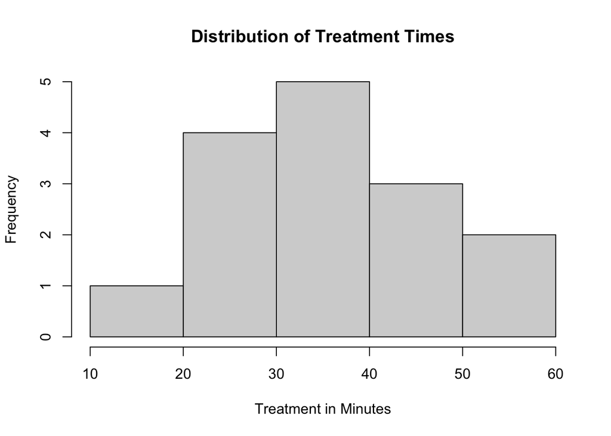

   ```r
   hist(treatments_data$TreatmentMinutes,
        main = "Distribution of Treatment Times",
        xlab = "Treatment in Minutes",
        ylab = "Frequency")
   ```

##Interpretation:

The histogram shows that treatment times are concentrated around 30–40 minutes. The distribution is not perfectly bell-shaped, but it appears roughly symmetric with no obvious extreme outliers. Since the sample contains only 15 observations, it is difficult to determine normality from the histogram alone.